# 02-monte-carlo-error

Zhuoyi Zhan

September 26, 2021

# 1 Introduction

Monte Carlo simulations are used to obtain probability of an uncertain events. Typically, the simulation will be repeated to get approximate results. Each simulation will have variability called error. We will explore the relationship of repetitions and simulation error.

## 1.1 Background

‘Monte Carlo Error’ is the standard deviation of the Monte Carlo estimator. It is uncertainty or variability between simulations. Its magnitudes depends on the setting of the experiment and the number of replicates.

The true probability is p, the estimated probability we get from simulation is p hat. There are two types of error. The actual amount of error between the actual value and the calculated value during a measurement is referred to ‘absolute error’. The ratio of the absolute error to the actual measurement is called the ‘relative error’.

$$Absolute Error=Actual value-Measured Value = p - p hat$$
$$Relative value =Absolute Error/Actual value = (p-phat)/p$$

# 2 Methods

```r
#install.packages("devtools")
#library(devtools)

#devtools::install_github("https://github.com/thomasgstewart/tgsify.git")
```

In this simulation, we will use probability of 0.01, 0.05, 0.1, 0.25, and 0.5. We will use the replicate numbers: 2^2, 2^3, …,2^15 times and graph the absolute and relative errors against the repeated times.

```r
require(tgsify)
# we first create a "container" to initialize the input parameters, 5 probability and replicate number from 2^2 to 2^15. It enables a 14 X 5 factorial simulation.
output <- expand.grid(
  N = 2^c(2:15)
  , P = c(0.01, 0.05, 0.10, 0.25, 0.50)
  , abs_error = NA
  , rel_error = NA
  , KEEP.OUT.ATTRS = FALSE
)

# we will generate 10000 observations each run
r <- 10000

for (i in 1: nrow(output)){
  p <- output$P[i]
  n <- output$N[i]
  phat <- rbinom(r,n,p)/n
  output[i, "abs_error"] <- mean(abs(phat-p))
  output[i, "rel_error"] <- mean(abs(phat-p)/p)
}
```

### 2.0.1 Figure: Absolute Error in log2 scale

```r
output %>%
  mutate(x = log2(N)) %>%
  mutate(col = as.factor(P) %>% as.numeric) %>%
  plotstyle(upright) %>%
  plot_setup(abs_error ~ x, c(0, 15), c(0,0.2)) %>%
  split(.$P) %>%
  lwith({
    lines(x, abs_error, col = col[1], lwd =5, type = "b", pch = 16)
    text(x[1], abs_error[1], "p="%|%P[1], pos =2)
  })
```

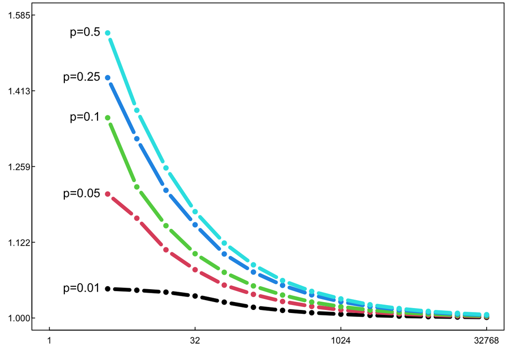

```r
axis(2, at = axTicks(2), labels= sprintf("%4.3f", 10^axTicks(2)), xlab="N(log2 scale)", ylab ="Absolute Error")
axis(1, at = axTicks(1), labels=2^axTicks(1))
box()
```

The absolute error decrease as the replicates number increase and the higher the probability, the higher the absolute error. For all five probability, they decrease drastically when less than 1024 and decrease little after 1024.

### 2.0.2 Figure: Absolute Error in log10 scale

```r
output %>%
  mutate(x=log2(N)) %>%
  mutate(abs_error =log10(abs_error)) %>%
  mutate(col = as.factor(P) %>% as.numeric) %>%
  plotstyle(upright) %>%
  plot_setup(abs_error ~ x, c(0, 15)) %>%
  split(.$P) %>%
  lwith({
    lines(x, abs_error, col = col[1], lwd =5, type = "b", pch = 16)
    text(x[1], abs_error[1], "p="%|%P[1], pos =2)
  })
```

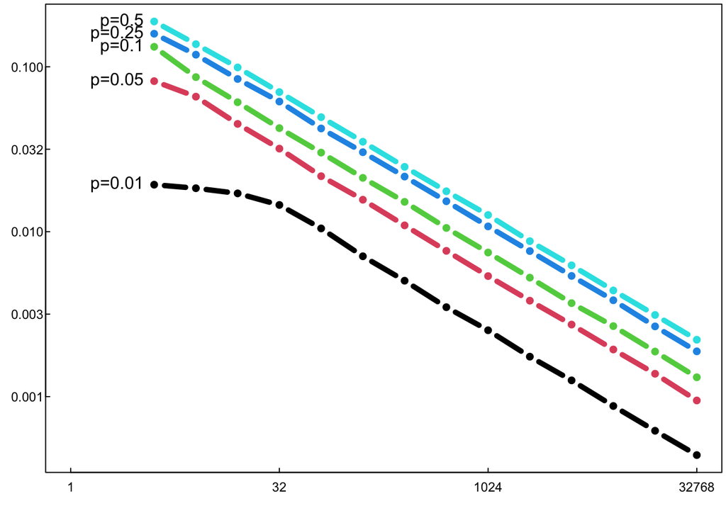

```r
axis(2, at = axTicks(2), labels= sprintf("%4.3f", 10^axTicks(2)))
axis(1, at = axTicks(1), labels=2^axTicks(1))
box()
```

The absolute error has a linear relationship with relates number. The higher the simulation replicates and the lower the probability, the lower the absolute error.

### 2.0.3 Figure: Relative Error in log2 scale

```r
output %>%
  mutate(x = log2(N)) %>%
  mutate(col = as.factor(P) %>% as.numeric) %>%
  plotstyle(upright) %>%
  plot_setup(rel_error ~ x, c(0, 15)) %>%
  split(.$P) %>%
  lwith({
    lines(x, rel_error, col = col[1], lwd =5, type = "b", pch = 16)
    text(x[1], rel_error[1], "p="%|%P[1], pos =2)
  })
```

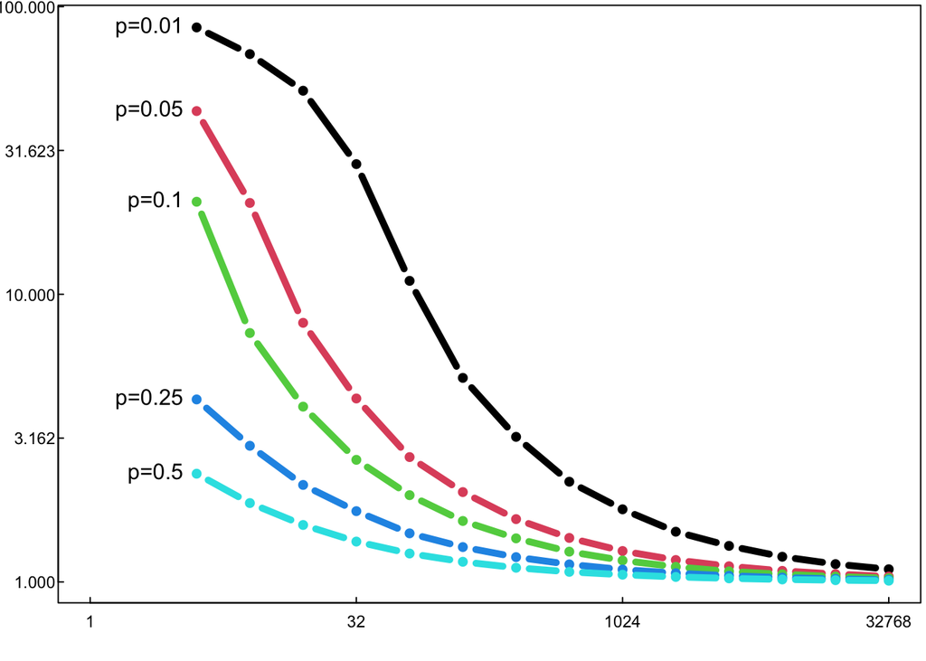

```r
axis(2, at = axTicks(2), labels= sprintf("%4.3f", 10^axTicks(2)))
axis(1, at = axTicks(1), labels=2^axTicks(1))
box()
```

The relative error decrease as the relates number increase and the lower the probability, the higher the absolute error. The relative errors decrease drastically when less than 1024 and decrease little after 1024.

### 2.0.4 Figure: Relative Error in log10 scale

```r
output %>%
  mutate(x = log2(N)) %>%
  mutate(rel_error =log10(rel_error)) %>%
  mutate(col = as.factor(P) %>% as.numeric) %>%
  plotstyle(upright) %>%
  plot_setup(rel_error ~ x, c(0, 15)) %>%
  split(.$P) %>%
  lwith({
    lines(x, rel_error, col = col[1], lwd =5, type = "b", pch = 16)
    text(x[1], rel_error[1], "p="%|%P[1], pos =2)
  })
```

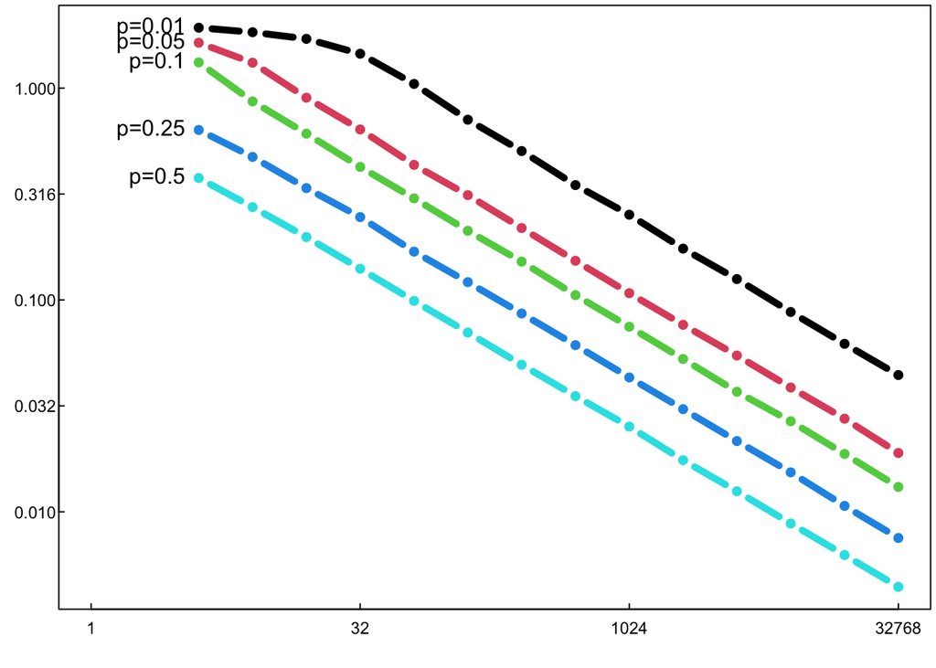

```r
axis(2, at = axTicks(2), labels= sprintf("%4.3f", 10^axTicks(2)))
axis(1, at = axTicks(1), labels=2^axTicks(1))
box()
```

The relative error has a linear relationship with relates number. The higher the simulation replicates and the higher the probability, the lower the absolute error.

# 3 Conclusions

From the four graphs, we can see that errors decrease as simulation replicate increase. When the replicate number is in log10 scale, the absolute error and relative error has a linear relationship with the replicates number. For absolute error the smaller the probability, the smaller the error while a smaller probability has higher relative error.